# Risk Factor Analysis

## Outcome Variable

**Outcome Variable:** wast_rec90d

## Predictor Variables

**Intervention Variable:** predfeed3

**Adjustment Set:**

unadjusted

## Stratifying Variables

The analysis was stratified on these variable(s):

- agecat
- studyid
- country

## Data Summary

| agecat | studyid | country | predfeed3 | wast_rec90d | n_cell | n |
| --- | --- | --- | --- | --- | --- | --- |
| 0-24 months | ki0047075b-MAL-ED | BANGLADESH | 0 | 0 | 5 | 118 |
| 0-24 months | ki0047075b-MAL-ED | BANGLADESH | 0 | 1 | 6 | 118 |
| 0-24 months | ki0047075b-MAL-ED | BANGLADESH | 1 | 0 | 37 | 118 |
| 0-24 months | ki0047075b-MAL-ED | BANGLADESH | 1 | 1 | 70 | 118 |
| 0-24 months | ki0047075b-MAL-ED | BRAZIL | 0 | 0 | 2 | 23 |
| 0-24 months | ki0047075b-MAL-ED | BRAZIL | 0 | 1 | 7 | 23 |
| 0-24 months | ki0047075b-MAL-ED | BRAZIL | 1 | 0 | 4 | 23 |
| 0-24 months | ki0047075b-MAL-ED | BRAZIL | 1 | 1 | 10 | 23 |
| 0-24 months | ki0047075b-MAL-ED | INDIA | 0 | 0 | 22 | 177 |
| 0-24 months | ki0047075b-MAL-ED | INDIA | 0 | 1 | 31 | 177 |
| 0-24 months | ki0047075b-MAL-ED | INDIA | 1 | 0 | 48 | 177 |
| 0-24 months | ki0047075b-MAL-ED | INDIA | 1 | 1 | 76 | 177 |
| 0-24 months | ki0047075b-MAL-ED | NEPAL | 0 | 0 | 5 | 92 |
| 0-24 months | ki0047075b-MAL-ED | NEPAL | 0 | 1 | 34 | 92 |
| 0-24 months | ki0047075b-MAL-ED | NEPAL | 1 | 0 | 15 | 92 |
| 0-24 months | ki0047075b-MAL-ED | NEPAL | 1 | 1 | 38 | 92 |
| 0-24 months | ki0047075b-MAL-ED | PERU | 0 | 0 | 1 | 32 |
| 0-24 months | ki0047075b-MAL-ED | PERU | 0 | 1 | 12 | 32 |
| 0-24 months | ki0047075b-MAL-ED | PERU | 1 | 0 | 5 | 32 |
| 0-24 months | ki0047075b-MAL-ED | PERU | 1 | 1 | 14 | 32 |
| 0-24 months | ki0047075b-MAL-ED | SOUTH AFRICA | 0 | 0 | 7 | 78 |
| 0-24 months | ki0047075b-MAL-ED | SOUTH AFRICA | 0 | 1 | 47 | 78 |
| 0-24 months | ki0047075b-MAL-ED | SOUTH AFRICA | 1 | 0 | 6 | 78 |
| 0-24 months | ki0047075b-MAL-ED | SOUTH AFRICA | 1 | 1 | 18 | 78 |
| 0-24 months | ki0047075b-MAL-ED | TANZANIA, UNITED REPUBLIC OF | 0 | 0 | 7 | 45 |
| 0-24 months | ki0047075b-MAL-ED | TANZANIA, UNITED REPUBLIC OF | 0 | 1 | 24 | 45 |
| 0-24 months | ki0047075b-MAL-ED | TANZANIA, UNITED REPUBLIC OF | 1 | 0 | 1 | 45 |
| 0-24 months | ki0047075b-MAL-ED | TANZANIA, UNITED REPUBLIC OF | 1 | 1 | 13 | 45 |
| 0-24 months | ki1000109-EE | PAKISTAN | 0 | 0 | 19 | 257 |
| 0-24 months | ki1000109-EE | PAKISTAN | 0 | 1 | 3 | 257 |

[output cut: 102 more lines]

The following strata were considered:

- agecat: 0-24 months, studyid: ki0047075b-MAL-ED, country: BANGLADESH
- agecat: 0-24 months, studyid: ki0047075b-MAL-ED, country: BRAZIL
- agecat: 0-24 months, studyid: ki0047075b-MAL-ED, country: INDIA
- agecat: 0-24 months, studyid: ki0047075b-MAL-ED, country: NEPAL
- agecat: 0-24 months, studyid: ki0047075b-MAL-ED, country: PERU
- agecat: 0-24 months, studyid: ki0047075b-MAL-ED, country: SOUTH AFRICA
- agecat: 0-24 months, studyid: ki0047075b-MAL-ED, country: TANZANIA, UNITED REPUBLIC OF
- agecat: 0-24 months, studyid: ki1000109-EE, country: PAKISTAN
- agecat: 0-24 months, studyid: ki1113344-GMS-Nepal, country: NEPAL
- agecat: 0-24 months, studyid: kiGH5241-JiVitA-3, country: BANGLADESH
- agecat: 0-24 months, studyid: kiGH5241-JiVitA-4, country: BANGLADESH
- agecat: 0-6 months, studyid: ki0047075b-MAL-ED, country: BANGLADESH
- agecat: 0-6 months, studyid: ki0047075b-MAL-ED, country: BRAZIL
- agecat: 0-6 months, studyid: ki0047075b-MAL-ED, country: INDIA
- agecat: 0-6 months, studyid: ki0047075b-MAL-ED, country: NEPAL
- agecat: 0-6 months, studyid: ki0047075b-MAL-ED, country: PERU
- agecat: 0-6 months, studyid: ki0047075b-MAL-ED, country: SOUTH AFRICA
- agecat: 0-6 months, studyid: ki0047075b-MAL-ED, country: TANZANIA, UNITED REPUBLIC OF
- agecat: 0-6 months, studyid: ki1000109-EE, country: PAKISTAN
- agecat: 0-6 months, studyid: ki1113344-GMS-Nepal, country: NEPAL
- agecat: 0-6 months, studyid: kiGH5241-JiVitA-3, country: BANGLADESH
- agecat: 0-6 months, studyid: kiGH5241-JiVitA-4, country: BANGLADESH
- agecat: 6-24 months, studyid: ki0047075b-MAL-ED, country: BANGLADESH
- agecat: 6-24 months, studyid: ki0047075b-MAL-ED, country: BRAZIL
- agecat: 6-24 months, studyid: ki0047075b-MAL-ED, country: INDIA
- agecat: 6-24 months, studyid: ki0047075b-MAL-ED, country: NEPAL
- agecat: 6-24 months, studyid: ki0047075b-MAL-ED, country: PERU
- agecat: 6-24 months, studyid: ki0047075b-MAL-ED, country: SOUTH AFRICA
- agecat: 6-24 months, studyid: ki0047075b-MAL-ED, country: TANZANIA, UNITED REPUBLIC OF
- agecat: 6-24 months, studyid: ki1000109-EE, country: PAKISTAN
- agecat: 6-24 months, studyid: ki1113344-GMS-Nepal, country: NEPAL
- agecat: 6-24 months, studyid: kiGH5241-JiVitA-3, country: BANGLADESH
- agecat: 6-24 months, studyid: kiGH5241-JiVitA-4, country: BANGLADESH

### Dropped Strata

Some strata were dropped due to rare outcomes:

- agecat: 0-24 months, studyid: ki0047075b-MAL-ED, country: BRAZIL
- agecat: 0-24 months, studyid: ki0047075b-MAL-ED, country: PERU
- agecat: 0-24 months, studyid: ki0047075b-MAL-ED, country: TANZANIA, UNITED REPUBLIC OF
- agecat: 0-24 months, studyid: ki1000109-EE, country: PAKISTAN
- agecat: 0-24 months, studyid: kiGH5241-JiVitA-4, country: BANGLADESH
- agecat: 0-6 months, studyid: ki0047075b-MAL-ED, country: BANGLADESH
- agecat: 0-6 months, studyid: ki0047075b-MAL-ED, country: BRAZIL
- agecat: 0-6 months, studyid: ki0047075b-MAL-ED, country: NEPAL
- agecat: 0-6 months, studyid: ki0047075b-MAL-ED, country: PERU
- agecat: 0-6 months, studyid: ki0047075b-MAL-ED, country: SOUTH AFRICA
- agecat: 0-6 months, studyid: ki0047075b-MAL-ED, country: TANZANIA, UNITED REPUBLIC OF
- agecat: 0-6 months, studyid: ki1000109-EE, country: PAKISTAN
- agecat: 0-6 months, studyid: kiGH5241-JiVitA-4, country: BANGLADESH
- agecat: 6-24 months, studyid: ki0047075b-MAL-ED, country: BANGLADESH
- agecat: 6-24 months, studyid: ki0047075b-MAL-ED, country: BRAZIL
- agecat: 6-24 months, studyid: ki0047075b-MAL-ED, country: NEPAL
- agecat: 6-24 months, studyid: ki0047075b-MAL-ED, country: PERU
- agecat: 6-24 months, studyid: ki0047075b-MAL-ED, country: SOUTH AFRICA
- agecat: 6-24 months, studyid: ki0047075b-MAL-ED, country: TANZANIA, UNITED REPUBLIC OF
- agecat: 6-24 months, studyid: ki1000109-EE, country: PAKISTAN
- agecat: 6-24 months, studyid: kiGH5241-JiVitA-3, country: BANGLADESH
- agecat: 6-24 months, studyid: kiGH5241-JiVitA-4, country: BANGLADESH

## Methods Detail

We’re interested in the causal parameters $E[Y_a]$ for all values of $a \in \mathcal{A}$. These parameters represent the mean outcome if, possibly contrary to fact, we intervened to set all units to have $A=a$. Under the randomization and positivity assumptions, these are identified by the statistical parameters $\psi_a=E_W[E_{Y|A,W}(Y|A=a,W)]$. In addition, we’re interested in the mean of $Y$, $E[Y]$ under no intervention (the observed mean). We will estimate these parameters by using SuperLearner to fit the relevant likelihood factors – $E_{Y|A,W}(Y|A=a,W)$ and $p(A=a|W)$, and then updating our likelihood fit using a joint TMLE.

For unadjusted analyses ($W=\{\}$), initial likelihoods were estimated using Lrnr_glm to estimate the simple $E(Y|A)$ and Lrnr_mean to estimate $p(A)$. For adjusted analyses, a small library containing Lrnr_glmnet, Lrnr_xgboost, and Lrnr_mean was used.

Having estimated these parameters, we will then use the delta method to estimate relative risks and attributable risks relative to a prespecified baseline level of $A$.

# Results Detail

## Results Plots

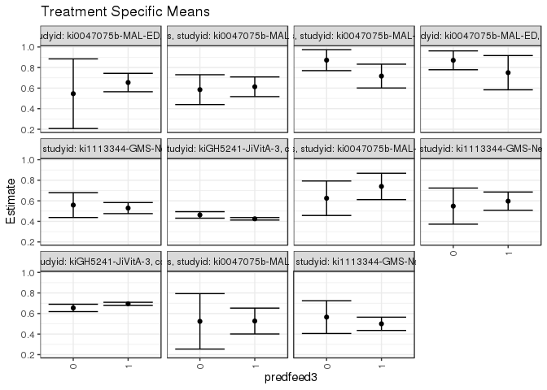

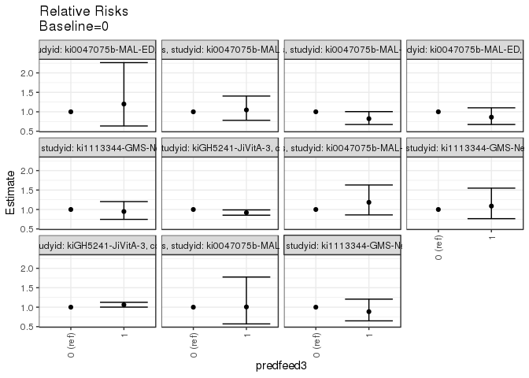

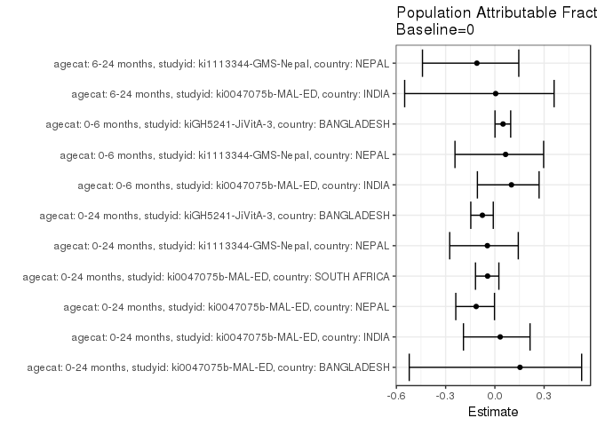

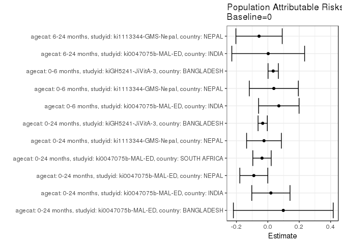

## Results Table

### Parameter: TSM

| agecat | studyid | country | intervention_level | baseline_level | estimate | ci_lower | ci_upper |
| --- | --- | --- | --- | --- | --- | --- | --- |
| 0-24 months | ki0047075b-MAL-ED | BANGLADESH | 0 | NA | 0.5454545 | 0.2068166 | 0.8840925 |
| 0-24 months | ki0047075b-MAL-ED | BANGLADESH | 1 | NA | 0.6542056 | 0.5647903 | 0.7436209 |
| 0-24 months | ki0047075b-MAL-ED | INDIA | 0 | NA | 0.5849057 | 0.4396427 | 0.7301686 |
| 0-24 months | ki0047075b-MAL-ED | INDIA | 1 | NA | 0.6129032 | 0.5173974 | 0.7084090 |
| 0-24 months | ki0047075b-MAL-ED | NEPAL | 0 | NA | 0.8717949 | 0.7698881 | 0.9737017 |
| 0-24 months | ki0047075b-MAL-ED | NEPAL | 1 | NA | 0.7169811 | 0.6011080 | 0.8328543 |
| 0-24 months | ki0047075b-MAL-ED | SOUTH AFRICA | 0 | NA | 0.8703704 | 0.7788517 | 0.9618891 |
| 0-24 months | ki0047075b-MAL-ED | SOUTH AFRICA | 1 | NA | 0.7500000 | 0.5833892 | 0.9166108 |
| 0-24 months | ki1113344-GMS-Nepal | NEPAL | 0 | NA | 0.5584416 | 0.4376550 | 0.6792281 |
| 0-24 months | ki1113344-GMS-Nepal | NEPAL | 1 | NA | 0.5292621 | 0.4753470 | 0.5831772 |
| 0-24 months | kiGH5241-JiVitA-3 | BANGLADESH | 0 | NA | 0.4625780 | 0.4309711 | 0.4941848 |
| 0-24 months | kiGH5241-JiVitA-3 | BANGLADESH | 1 | NA | 0.4249412 | 0.4128184 | 0.4370640 |
| 0-6 months | ki0047075b-MAL-ED | INDIA | 0 | NA | 0.6250000 | 0.4572758 | 0.7927242 |
| 0-6 months | ki0047075b-MAL-ED | INDIA | 1 | NA | 0.7400000 | 0.6118154 | 0.8681846 |
| 0-6 months | ki1113344-GMS-Nepal | NEPAL | 0 | NA | 0.5483871 | 0.3726315 | 0.7241427 |
| 0-6 months | ki1113344-GMS-Nepal | NEPAL | 1 | NA | 0.5966387 | 0.5078041 | 0.6854732 |
| 0-6 months | kiGH5241-JiVitA-3 | BANGLADESH | 0 | NA | 0.6544118 | 0.6186486 | 0.6901749 |
| 0-6 months | kiGH5241-JiVitA-3 | BANGLADESH | 1 | NA | 0.6946154 | 0.6801621 | 0.7090687 |
| 6-24 months | ki0047075b-MAL-ED | INDIA | 0 | NA | 0.5238095 | 0.2539728 | 0.7936463 |
| 6-24 months | ki0047075b-MAL-ED | INDIA | 1 | NA | 0.5270270 | 0.4012790 | 0.6527751 |
| 6-24 months | ki1113344-GMS-Nepal | NEPAL | 0 | NA | 0.5652174 | 0.4059418 | 0.7244930 |
| 6-24 months | ki1113344-GMS-Nepal | NEPAL | 1 | NA | 0.5000000 | 0.4354869 | 0.5645131 |

### Parameter: E(Y)

| agecat | studyid | country | intervention_level | baseline_level | estimate | ci_lower | ci_upper |
| --- | --- | --- | --- | --- | --- | --- | --- |
| 0-24 months | ki0047075b-MAL-ED | BANGLADESH | NA | NA | 0.6440678 | 0.5565826 | 0.7315530 |
| 0-24 months | ki0047075b-MAL-ED | INDIA | NA | NA | 0.6045198 | 0.5246128 | 0.6844268 |
| 0-24 months | ki0047075b-MAL-ED | NEPAL | NA | NA | 0.7826087 | 0.7016344 | 0.8635829 |
| 0-24 months | ki0047075b-MAL-ED | SOUTH AFRICA | NA | NA | 0.8333333 | 0.7515924 | 0.9150742 |
| 0-24 months | ki1113344-GMS-Nepal | NEPAL | NA | NA | 0.5340426 | 0.4848509 | 0.5832342 |
| 0-24 months | kiGH5241-JiVitA-3 | BANGLADESH | NA | NA | 0.4298760 | 0.4185519 | 0.4412000 |
| 0-6 months | ki0047075b-MAL-ED | INDIA | NA | NA | 0.6951220 | 0.5922224 | 0.7980215 |
| 0-6 months | ki1113344-GMS-Nepal | NEPAL | NA | NA | 0.5866667 | 0.5072781 | 0.6660552 |
| 0-6 months | kiGH5241-JiVitA-3 | BANGLADESH | NA | NA | 0.6886463 | 0.6752359 | 0.7020567 |
| 6-24 months | ki0047075b-MAL-ED | INDIA | NA | NA | 0.5263158 | 0.4116286 | 0.6410029 |
| 6-24 months | ki1113344-GMS-Nepal | NEPAL | NA | NA | 0.5093750 | 0.4496016 | 0.5691484 |

### Parameter: RR

| agecat | studyid | country | intervention_level | baseline_level | estimate | ci_lower | ci_upper |
| --- | --- | --- | --- | --- | --- | --- | --- |
| 0-24 months | ki0047075b-MAL-ED | BANGLADESH | 0 | 0 | 1.0000000 | 1.0000000 | 1.000000 |
| 0-24 months | ki0047075b-MAL-ED | BANGLADESH | 1 | 0 | 1.1993769 | 0.6350804 | 2.265076 |
| 0-24 months | ki0047075b-MAL-ED | INDIA | 0 | 0 | 1.0000000 | 1.0000000 | 1.000000 |
| 0-24 months | ki0047075b-MAL-ED | INDIA | 1 | 0 | 1.0478668 | 0.7815997 | 1.404843 |
| 0-24 months | ki0047075b-MAL-ED | NEPAL | 0 | 0 | 1.0000000 | 1.0000000 | 1.000000 |
| 0-24 months | ki0047075b-MAL-ED | NEPAL | 1 | 0 | 0.8224195 | 0.6733193 | 1.004537 |
| 0-24 months | ki0047075b-MAL-ED | SOUTH AFRICA | 0 | 0 | 1.0000000 | 1.0000000 | 1.000000 |
| 0-24 months | ki0047075b-MAL-ED | SOUTH AFRICA | 1 | 0 | 0.8617021 | 0.6737479 | 1.102090 |
| 0-24 months | ki1113344-GMS-Nepal | NEPAL | 0 | 0 | 1.0000000 | 1.0000000 | 1.000000 |
| 0-24 months | ki1113344-GMS-Nepal | NEPAL | 1 | 0 | 0.9477484 | 0.7461299 | 1.203848 |
| 0-24 months | kiGH5241-JiVitA-3 | BANGLADESH | 0 | 0 | 1.0000000 | 1.0000000 | 1.000000 |
| 0-24 months | kiGH5241-JiVitA-3 | BANGLADESH | 1 | 0 | 0.9186369 | 0.8530745 | 0.989238 |
| 0-6 months | ki0047075b-MAL-ED | INDIA | 0 | 0 | 1.0000000 | 1.0000000 | 1.000000 |
| 0-6 months | ki0047075b-MAL-ED | INDIA | 1 | 0 | 1.1840000 | 0.8602357 | 1.629618 |
| 0-6 months | ki1113344-GMS-Nepal | NEPAL | 0 | 0 | 1.0000000 | 1.0000000 | 1.000000 |
| 0-6 months | ki1113344-GMS-Nepal | NEPAL | 1 | 0 | 1.0879881 | 0.7640980 | 1.549171 |
| 0-6 months | kiGH5241-JiVitA-3 | BANGLADESH | 0 | 0 | 1.0000000 | 1.0000000 | 1.000000 |
| 0-6 months | kiGH5241-JiVitA-3 | BANGLADESH | 1 | 0 | 1.0614347 | 1.0011457 | 1.125354 |
| 6-24 months | ki0047075b-MAL-ED | INDIA | 0 | 0 | 1.0000000 | 1.0000000 | 1.000000 |
| 6-24 months | ki0047075b-MAL-ED | INDIA | 1 | 0 | 1.0061425 | 0.5703223 | 1.775001 |
| 6-24 months | ki1113344-GMS-Nepal | NEPAL | 0 | 0 | 1.0000000 | 1.0000000 | 1.000000 |
| 6-24 months | ki1113344-GMS-Nepal | NEPAL | 1 | 0 | 0.8846154 | 0.6486774 | 1.206369 |

### Parameter: PAR

| agecat | studyid | country | intervention_level | baseline_level | estimate | ci_lower | ci_upper |
| --- | --- | --- | --- | --- | --- | --- | --- |
| 0-24 months | ki0047075b-MAL-ED | BANGLADESH | 0 | NA | 0.0986133 | -0.2193500 | 0.4165765 |
| 0-24 months | ki0047075b-MAL-ED | INDIA | 0 | NA | 0.0196141 | -0.1021089 | 0.1413372 |
| 0-24 months | ki0047075b-MAL-ED | NEPAL | 0 | NA | -0.0891862 | -0.1782293 | -0.0001430 |
| 0-24 months | ki0047075b-MAL-ED | SOUTH AFRICA | 0 | NA | -0.0370370 | -0.0955878 | 0.0215137 |
| 0-24 months | ki1113344-GMS-Nepal | NEPAL | 0 | NA | -0.0243990 | -0.1351746 | 0.0863766 |
| 0-24 months | kiGH5241-JiVitA-3 | BANGLADESH | 0 | NA | -0.0327020 | -0.0621165 | -0.0032875 |
| 0-6 months | ki0047075b-MAL-ED | INDIA | 0 | NA | 0.0701220 | -0.0588056 | 0.1990495 |
| 0-6 months | ki1113344-GMS-Nepal | NEPAL | 0 | NA | 0.0382796 | -0.1179078 | 0.1944669 |
| 0-6 months | kiGH5241-JiVitA-3 | BANGLADESH | 0 | NA | 0.0342345 | 0.0013856 | 0.0670834 |
| 6-24 months | ki0047075b-MAL-ED | INDIA | 0 | NA | 0.0025063 | -0.2293732 | 0.2343857 |
| 6-24 months | ki1113344-GMS-Nepal | NEPAL | 0 | NA | -0.0558424 | -0.2034345 | 0.0917498 |

### Parameter: PAF

| agecat | studyid | country | intervention_level | baseline_level | estimate | ci_lower | ci_upper |
| --- | --- | --- | --- | --- | --- | --- | --- |
| 0-24 months | ki0047075b-MAL-ED | BANGLADESH | 0 | NA | 0.1531100 | -0.5217649 | 0.5286903 |
| 0-24 months | ki0047075b-MAL-ED | INDIA | 0 | NA | 0.0324458 | -0.1914221 | 0.2142490 |
| 0-24 months | ki0047075b-MAL-ED | NEPAL | 0 | NA | -0.1139601 | -0.2380747 | -0.0022878 |
| 0-24 months | ki0047075b-MAL-ED | SOUTH AFRICA | 0 | NA | -0.0444444 | -0.1181059 | 0.0243642 |
| 0-24 months | ki1113344-GMS-Nepal | NEPAL | 0 | NA | -0.0456874 | -0.2752195 | 0.1425303 |
| 0-24 months | kiGH5241-JiVitA-3 | BANGLADESH | 0 | NA | -0.0760731 | -0.1467345 | -0.0097658 |
| 0-6 months | ki0047075b-MAL-ED | INDIA | 0 | NA | 0.1008772 | -0.1064865 | 0.2693794 |
| 0-6 months | ki1113344-GMS-Nepal | NEPAL | 0 | NA | 0.0652493 | -0.2430486 | 0.2970839 |
| 0-6 months | kiGH5241-JiVitA-3 | BANGLADESH | 0 | NA | 0.0497128 | 0.0007611 | 0.0962664 |
| 6-24 months | ki0047075b-MAL-ED | INDIA | 0 | NA | 0.0047619 | -0.5496396 | 0.3608199 |
| 6-24 months | ki1113344-GMS-Nepal | NEPAL | 0 | NA | -0.1096292 | -0.4410898 | 0.1455931 |